# Eddie Module on Nutrient Loading

Note this is essentially the same thing as the water quality module and I think there is an issue with the set up as it is not correct

# Install the basic libraries

```r
# install.packages("tidyverse")
# install.packages("readxl")
# install.packages("janitor")
# install.packages("lubridate")
# install.packages("broom")
# install.packages("patchwork")
# install.packages("skimr")
```

# Load libraries

Load the libraries each time you run a script or program

```r
library(tidyverse) # loads a lot of libraries in this one to add more functionality
library(readxl) # allows you to read in excel files
library(janitor) # cleans up column names and removes empty columns if wanted
library(lubridate) # allows easy conversion of varaibles to date format
library(broom) # cleans up output for easy presentation
library(patchwork)
library(skimr)
```

# Read in files

Decar River in Palo Iowa 15 mintue data

```r
decar.df <- read_excel("../data/nutrient_loading_module_data.xlsx",
                    sheet = "decar_river_palo_iowa")
```

# Recalculate columns for reproducibility

The conversion of cubic feet per second to liters required CFS to be multiplied by 28.136

```r
decar.df <- decar.df %>%
  mutate(time_int_load_kgn = discharge_cfs * nitrate_n_mgl * 28.136 * 15 * (60/1000000),
         time_int__q_l = discharge_cfs *28.136*15*60)
```

# Plot of nitrate versus time

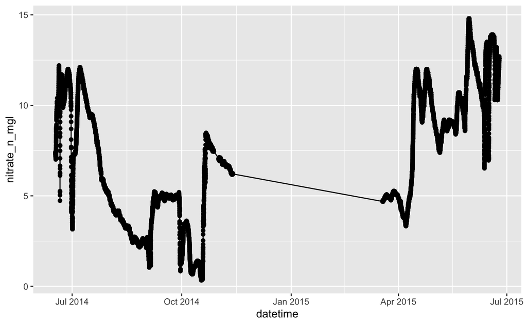

```r
decar.df %>%
  ggplot(aes(x=datetime, y =nitrate_n_mgl)) +
  geom_line() +
  geom_point()
```

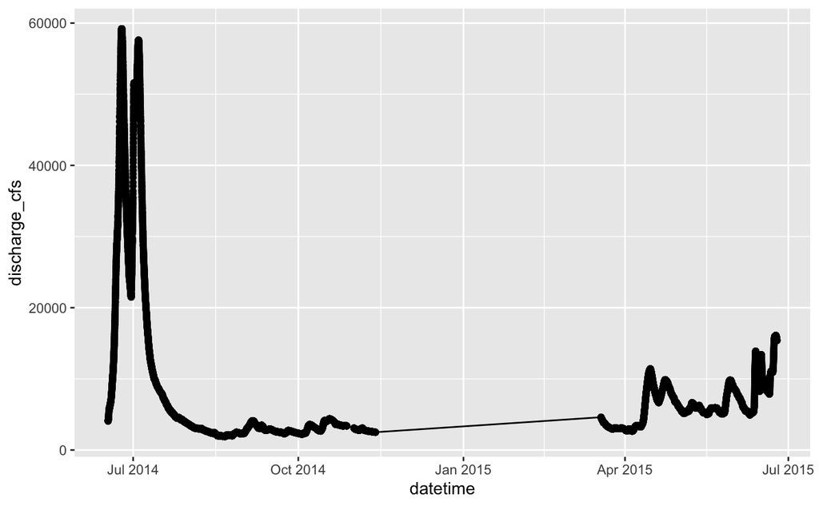

```r
decar.df %>%
  ggplot(aes(x=datetime, y =discharge_cfs)) +
  geom_line() +
  geom_point()
```